# Final Project

Caterina Coccia

10/9/2021

# Abstract

Starting from classical inference, Bayesian inference moves one step forward, in the sense that now the parameters that generate observable data are no longer consideren unknown but fixed. Such parameters are indeed thought as random, and thus they can be modeled by an appropriate probability distribution. In this paper, several tools of Bayesian analysis will be implemented on a real set of observed data. The dataset includes audio features evaluated for some past decade's songs and made available via the official Spotify Web API [Source: https://www.kaggle.com/theoverman/the-spotify-hit-predictor-dataset?select=dataset-of-10s.csv].

# Introduction

Bayesian inference uses a fully probabilistic setting to represent our phenomenon of interest. Its two main ingredients are the likelihood $f(\underline{y}|\theta)$ and the prior distribution $\pi(\theta)$. The former consists in a probabilistic representation of the observable data conditinally on an unknown parameter value $\theta$; while the latter indicates our initial beliefs about $\theta$. Applying Bayes' theorem, it is possible to update our state of uncertainty about the parameter of interest once some data has been observed. Operatively, such update is obtained by computing the posterior distribution $\pi(\theta|\underline{y})$, which is proportional to the product between the likelihood and the prior. It is possible to perform some inference on the posterior: for instance we can compute summaries of $\pi(\theta|\underline{y})$ as point estimates or quantile-based quantities for obtaining confidence intervals. Unfortunately, sometimes obtaining exact values for these posterior quantities can be challenging. On the other hand, if we could generate a random sample of parameters values from the posterior distribution, then all posterior quantities could be approximated by means of the Monte Carlo method. Let $\theta$ be our parameter of interest, suppose that we are able to simulate a number S of independent, random $\theta$-values from the posterior:
$$\theta^{1}, ..., \theta^{S} \sim \pi(\theta|\underline{y})$$
These simulations would be independent and identical distributed (iid) and their empirical distribution would approximate $\pi(\theta|\underline{y})$, with the approximatin improving as S gets larger. Monte Carlo method does not actually provide more insight about $\theta$, it is simply a different way of looking at the posterior distribution. However, even the Monte Carlo method comes with its own difficulties. As a matter of fact, direct iid simulation from the posterior can be difficult for distributions outside the well-known parametric families or when we are dealing with a multiparametric setting. It may be easier to generate MCMC simulations (Markov Chain Monte Carlo). This method differs from the previous one in the sense that now there is a dependence structure behind the generated $\theta$-values.

# Description of the real dataset

The selected dataset consists of features for tracks fetched using Spotify's Web API. Such platform provides access to metadata about music artists, albums and songs directly from the Spotify Data Catalogue. In this case, the author decided to split the data into multiple files, according to the decade in which each track was published. In this project we will focus on the most recent decade, therefore the songs we will deal with were all published between January 1<sup>st</sup> 2010 and December 31<sup>st</sup> 2019. The dataset presents no missing values and it is composed by 6398 observations and 19 variables. However, we are restricting our analysis to the following variables:

1. "**target**", it represents the popularity of each track. It can only take two values: 0 indicates a "*non popular*" song while 1 stands for "*popular*".
2. "**danceability**", describes how suitable a track is for dancing, based on a combination of musical elements including tempo, rhythm stability, beat strenght. A value of 0.0 is for "*least danceable*" songs and 1.0 is for "*most danceable*" ones.
3. "**duration_ms**", the duration of the track in milliseconds.
4. "**instrumentalness**", predicts whether or not a track contains vocals (i.e. rap or spoken word tracks are clearly "*vocal*"). This variable ranges from 0.0 to 1.0. The closer the instrumentalness value is to 1.0, the greater likelihood the track contains no vocal content: values above 0.5 are intended to represent instrumental tracks, but confidence is higher as the value approaches 1.0.
5. "**loudness**", The overall loudness of a track in decibels (dB). Loudness values are averaged across the entire track and are useful for comparing relative loudness of tracks. Loudness is the quality of a sound that is the primary psychological correlate of physical strength (amplitude). Values typical range between -60 and 0 db.

The *target* variable is binary: a song can be either "popular" or "not popular"; *danceability*, *instrumentalness* and *loudness* are continuous variabes in the respective domains; *duration_ms* takes non-negative values ranging from 29.853 to 1734.201 (i.e. from half a minute to approximately 29 minutes). For a better interpretation, milliseconds will be converted into minutes.

```r
library(readr)
dataset_of_10s <- read_csv("~/Desktop/OFFICIAL STATISTICS/BAYESIAN MODELLING/Progetti/dataset-of-10s.csv",
    col_types = cols(uri = col_skip()))

# there are no missing values
anyNA(dataset_of_10s)
```

```
## [1] FALSE
```

```r
# let's select the variables of interest and convert milliseconds in minutes
reduced_dataset <- dataset_of_10s[, c(1, 2, 3, 6, 10, 14, 18)]
reduced_dataset$duration <- reduced_dataset$duration_ms/(1000 * 60)
reduced_dataset <- reduced_dataset[, -6]
```

## Descriptive analysis

To provide an overview on the selected dataset, let's perform a descriptive analysis. The characteristic of interest in this case would be the popularity of the tracks. We may note that exactly half of the observed songs are labelled as "*popular*" and the remaining half are considered "*not popular*".

```r
table(reduced_dataset$target)
```

```
##
##    0    1
## 3199 3199
```

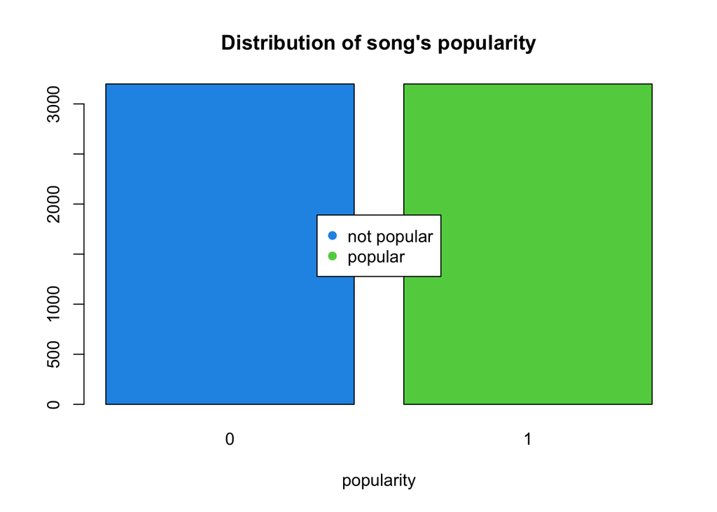

```r
barplot(table(reduced_dataset$target), col = reduced_dataset$target + 19, main = "Distribution of song's popularity",
    xlab = "popularity")
legend("center", legend = c("not popular", "popular"), col = reduced_dataset$target +
    19, pch = 19)
```

The popularity of the tracks seems to be influenced by the aforementioned variables. To further investigate this relationships, we may observe the following series of boxplots. A boxplot is a type of graphical representation that summarizes the most important characteristics of a distribution. Here they have been presented by splitting the distributions according to the variable *target*. As a matter of fact, popular songs tend to be more "*danceable*": this variable's average score is 0.49 for not popular songs and 0.64 for the popular ones. The distribution of the *duration* of popular songs appears concentrated around its mean value of 3 minutes and a half. This result may be due to factors such as usual radio time dedicated to each track: typically, very long tracks are less likely to be played by radio channels, therefore influencing their popularity. The extreme differences in the *instrumentalness* boxplot give us some insight about the preferred musical genre for most popular songs. As mentioned above, a score of instrumentalness close to zero represents a track mostly characterized by the presence of spoken words, and this is known to be the peculiarity of rap music, for istance. In general, we understand that songs with long instrumental parts are clearly less appreciated: basically all popular songs are characterized by instrumentalness score close to 0. Also, popular songs turn out to be generally louder than not popular ones. In the former case, the distribution is more concentrated around the mean of -5.88 versus a mean value of -9.30 in the latter, where the *loudness* also presents a higher variability.

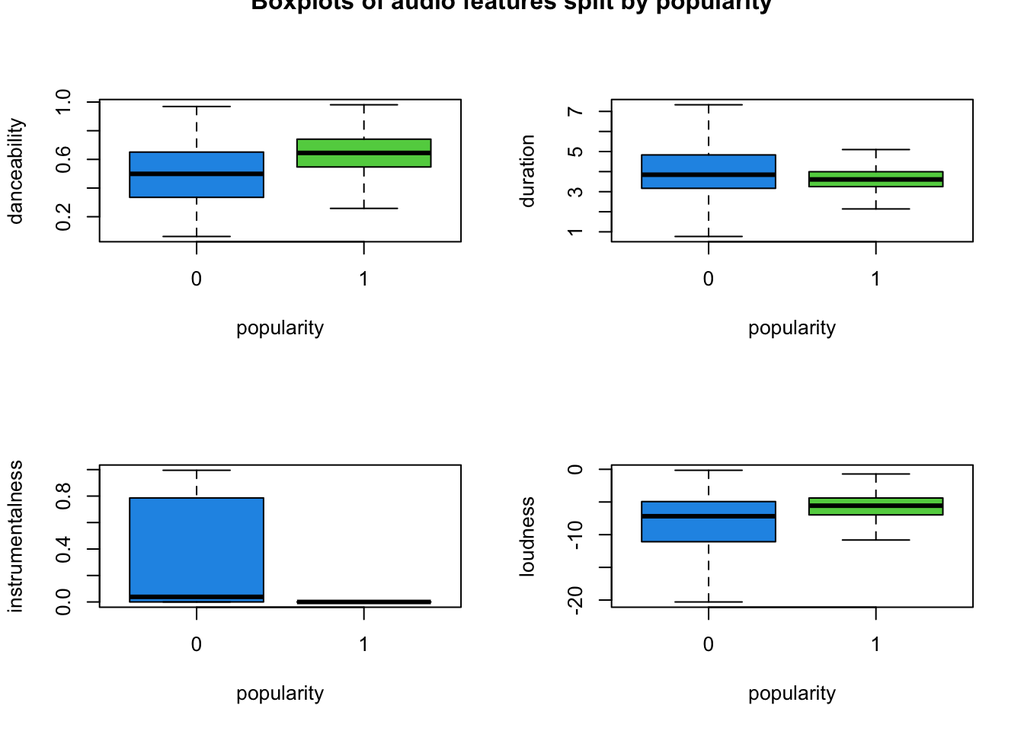

```r
par(mfrow = c(2, 2))

boxplot(reduced_dataset$danceability ~ reduced_dataset$target, col = reduced_dataset$target +
    19, ylab = "danceability", xlab = "popularity", outline = F)

boxplot(reduced_dataset$duration ~ reduced_dataset$target, col = reduced_dataset$target +
    19, ylab = "duration", xlab = "popularity", outline = F)

boxplot(reduced_dataset$instrumentalness ~ reduced_dataset$target, col = reduced_dataset$target +
    19, ylab = "instrumentalness", xlab = "popularity", outline = F)

boxplot(reduced_dataset$loudness ~ reduced_dataset$target, col = reduced_dataset$target +
    19, ylab = "loudness", xlab = "popularity", outline = F)

title("Boxplots of audio features split by popularity", outer = T)
```

```r
round(tapply(reduced_dataset$danceability, reduced_dataset$target, mean), 2)
```

```
##    0    1
## 0.49 0.64
```

```r
round(tapply(reduced_dataset$duration, reduced_dataset$target, mean), 2)
```

```
##    0    1
## 4.22 3.68
```

```r
round(tapply(reduced_dataset$instrumentalness, reduced_dataset$target, mean), 2)
```

```
##    0    1
## 0.32 0.01
```

```r
round(tapply(reduced_dataset$loudness, reduced_dataset$target, mean), 2)
```

```
##     0     1
## -9.30 -5.88
```

These first results suggest that songs' popularity is associated to higher levels of *danceability* and *loudness*, great presence of spoken words in the track and a moderate duration. To better display such relationships, the correlation matrix has been computed. As expected, our *target* variable is positively correlated with *danceability* ($\sigma_{target,danceability} = 0.38)$ and *loudness* ($\sigma_{target,loudness} = 0.33$). On the other hand, negative correlation has been registered with respect to *instrumentalness* ($\sigma_{target,instrumentalness} = -0.50$) and, even though far smaller, *duration* ($\sigma_{target,duration} = -0.19$).

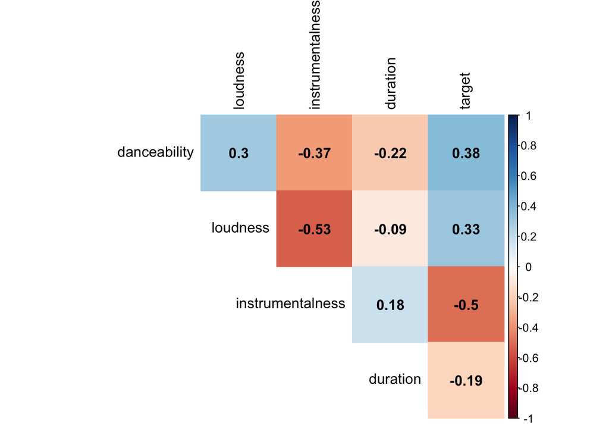

```r
library("corrplot", lib.loc = "/Library/Frameworks/R.framework/Versions/4.0/Resources/library")
C_red <- cor(reduced_dataset[, c(3, 4, 5, 7, 6)])
corrplot(C_red, method = "color", type = "upper", diag = F, addCoef.col = "black",
    tl.col = "black")
```

# Bayesian analysis

The Bayesian approach uses a fully probabilistic representation of the phenomenon of interest. The starting point is once again our observed data vector $y_1, ..., y_n$, which can be thought as sampled form a probabilistic model described by $f_{\underline{Y_n}}(\underline{y_n}|\theta)$ and depending on the unknown parameter of interest $\theta$. According to the Bayesian analysis, the parameter itself is considered as a random variable, thus it can be properly modeled by a suitable probability law, called *prior distribution*: $\pi(\theta)$. Essentially, the prior describes our initial beliefs about the unknown parameter. In this setting it is assumed that sampled values are identically distributed and independent, conditionally on $\theta$. The idea behind Bayesian framework is that, once the data has been observed, we can update our state of uncertainty around $\theta$ by following Bayes' theorem:
$$\pi(\theta| \underline{y_n}) \propto \pi(\theta) * \prod_{i=1}^n f_{Y_i}(y_i|\theta)$$
namely:
$$posterior \propto prior * likelihood$$
where the *posterior distribution* formalizes the probability law of $\theta$ in light of the observed data $Y_1=y_1^{obs},...,Y_n=y_n^{obs}$. Starting from an initial state of uncertainty ($\pi(\theta)$), this approach leads to its update based both on prior knowledge and on observed data. Quality of posterior distribution may depend on quantity as well as on quality of the observed data. Furthermore, we can make inference and derive some quantities of interest from the posterior distribution.

The most convenient way of deriving the posterior is to select a prior distribution that has the same funcional form as the likelihood. A parametric class $P = \{ \pi_h(\theta); h \in H \}$ of prior distributions for the unknown parameter $\theta \in \Theta$ is defined conjugate for a model $f_{\underline{Y_n}}(\underline{y_n}|\theta)$ if:
$$\pi_h(.) \in P \Rightarrow \pi(. |\underline{y_n}) \in P$$

Conjugacy is a model-related property of a parametric class of prior distributions. The prior class is conjugate with a statistical model. As for the dataset presented in ths paper, an appropriate conjugate analysis would be based on a Bernoulli model and a Beta prior. In fact, our *target* variable can only take two possible values, either 0 for "not popular" or 1 for "popular" songs. Therefore, our model specification could be the following:
$$Y_i|\theta \sim Bernoulli(\theta)$$
$$\theta \sim Beta(\alpha, \beta)$$
where $Y_1,...,Y_n|\theta$ are iid and $\theta \in \Theta = \{0,1\}$; $\alpha, \beta > 0$ are known and are called hyperparameters, namely prior parameters. Note that the prior distribution must be defined over the parametric space $\Theta$. The two elements needed for carrying out our conjugate analysis are the prior distribution and the likeihood, respectively equal to:
$$\pi(\theta) = \frac{1}{ B(\alpha, \beta)} * \theta^{\alpha - 1} * (1-\theta)^{\beta -1}$$
$$f_{\underline{Y_n}}(\underline{y_n}|\theta) = \prod_{i=1}^n f_{Y_i}(y_i|\theta) = \prod_{i=1}^n \theta^{x_i} * (1-\theta)^{1-x_i}$$
As a consequence, the following posterior will be obtained:
$$\pi(\theta |\underline{y_n} ) \propto \theta^{(\alpha + \sum_{i=1}^n x_i) - 1} * (1-\theta)^{(\beta + n - \sum_{i=1}^n x_i) -1}$$
By fixing $\alpha_{post} = \alpha + \sum_{i=1}^n x_i$ and $\beta_{post} = \beta + n - \sum_{i=1}^n x_i$ as posterior parameters, we obtain that:
$$\pi(\theta |\underline{y_n}) \sim Beta(\alpha_{post},\beta_{post})$$
Let us notice that posterior parameters depend on initial prior parameters as well as on information coming from the observed data.

In order to implement this analysis on our real dataset, we need to specify a prior distribution describing our initial state of uncertainty around $\theta$. Because we are not provided with any additional information, we opt for a vague prior specification, in which $\alpha = \beta = 1$. This type of choice actually consists in a Uniform prior distribution defined in the interval $[0,1]$. Once the posterior is computed, we have a more precise idea on what the distribution of $\theta$ looks like. Even though there is actually no difference between prior expectation and posterior expectation, we are now more "confident" that the expected value for $\theta$ is indeed equal to 0.5. Moreover, the variability in the posterior is heavily reduced.

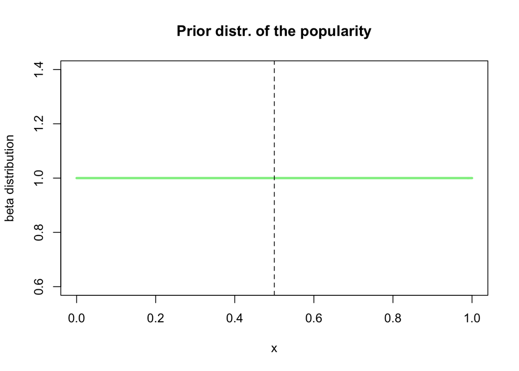

```r
n <- length(reduced_dataset$target)
s <- sum(reduced_dataset$target)
alpha_prior <- 1
beta_prior <- 1
alpha_post <- alpha_prior + s
beta_post <- beta_prior + n - s
prior_exp <- alpha_prior/(alpha_prior + beta_prior)
post_exp <- alpha_post/(alpha_post + beta_post)

curve(dbeta(x, alpha_prior, beta_prior), lwd = 3, col = "lightgreen", main = "Prior distr. of the popularity",
    ylab = "beta distribution")
abline(v = prior_exp, lty = "dashed")
```

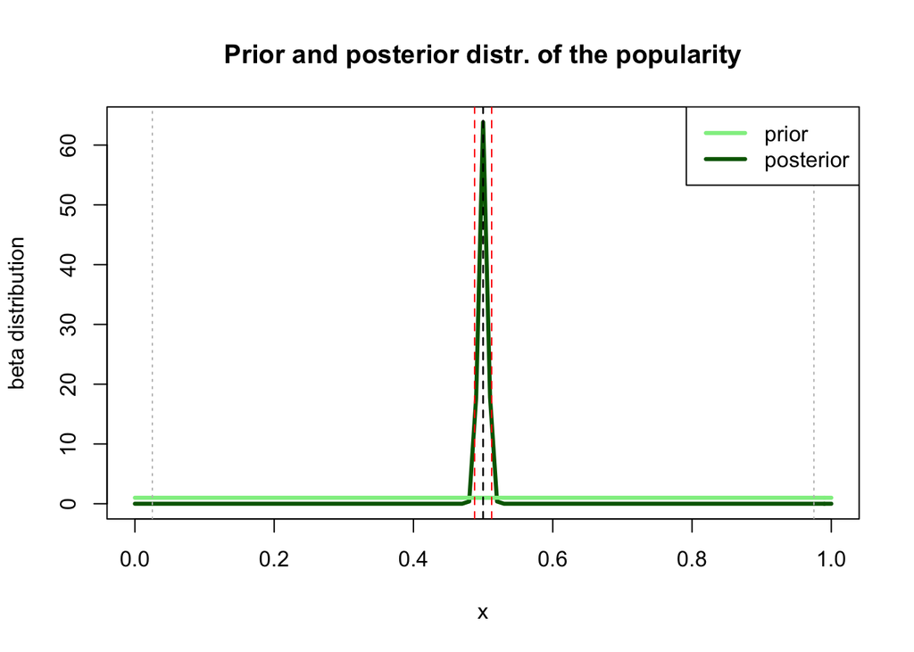

```r
curve(dbeta(x, alpha_post, beta_post), lwd = 3, col = "darkgreen", main = "Prior and posterior distr. of the popularity",
    ylab = "beta distribution")
curve(dbeta(x, alpha_prior, beta_prior), lwd = 3, col = "lightgreen", add = T)
abline(v = prior_exp, lty = "dashed")
abline(v = post_exp, lty = "dashed")

g <- 0.05
abline(v = qbeta(g/2, alpha_post, beta_post), lty = "dashed", col = "red")
abline(v = qbeta(1 - g/2, alpha_post, beta_post), lty = "dashed", col = "red")
abline(v = qbeta(g/2, alpha_prior, beta_prior), lty = "dotted", col = "grey")
abline(v = qbeta(1 - g/2, alpha_prior, beta_prior), lty = "dotted", col = "grey")
legend("topright", legend = c("prior", "posterior"), col = c("lightgreen", "darkgreen"),
    lwd = 3)
```

# Logistic regression model

In order to go further in our analysis of a real dataset, let's proceed with implementing a logistic regression model. In general, we often want to model the relationship between some response variable $Y$ and predictors $X_1,...,X_k$. If we are dealing with a quantitative response variable $Y$, we will consider a regression model, whose aim would be understanding if and how the variability of the predictors influences that of the response variable. The present framework lies in a particular case: our $Y$, namely the *target* variable, is a binary response variable: $Y_i = 1$ if the i-th song is popular, $Y_i = 0$ otherwise. It basically consists in an indicator of wheter or not a track is popular. As for the predictors, we are considering: $X_1$ = danceability, $X_2$ = duration, $X_3$ = instrumentalness and $X_4$ = loudness. Because $Y_i$ is a discrete variable which only takes values 0 and 1, the best probability model is the following:
$$Y_i|\theta_i \sim Bernoulli(\theta_i)$$
with expected value $E(Y_i | \theta_i) = \theta_i$. Here $\theta_i$ denotes the probability that the i-th song is popular. To assess how the expected value depends on our predictors, the logistic regression identifies a suitable function of $\theta_i$, the logit link function, that expresses this relationship through a linear function:
$$\log(\frac{\theta_i}{ 1-\theta_i}) = \beta_0 + \beta_1*X_1 + \beta_2*X_2 + \beta_3 * X_3 + \beta_4*X_4$$
Thus, we are assuming that the logaritm of the odds of a song's popularity is linearly related to the aforementioned predictors. Note that the quantity $\frac{\theta_i}{ 1-\theta_i}$ defines the concept of odds, which consists in the ratio between the probability that the event happens and the probability that the same event doesn't happen. Also, while $\theta_i$ indicates a probability and therefore belongs to the interval $[0,1]$, odds can range form 0 to infinity. The logit function then takes the logaritm of the odds, thus providing an easier, linear relation between the components of our model. Moreover, we may note that the regression coefficients $\beta_0, \beta_1, \beta_2, \beta_3, \beta_4$ take on the usual intercept and slope meanings when describing the linear relationship between the predictors and the log odds of a song being popular. To complete the Bayesian logistic regresson model, we must specify the prior distribution referring to each regression parameter. Since they can take possibly any real value, the most appropriate choice would be a Normal prior. Generally, if we lack more precise information, such prior distributions should be centered around zero, to indicate that the associated predictor might not have an influence on the response variable. Our model is specified as follows:
$$popularity_i \sim Bernoulli(\theta_i)$$
$$\log(\frac{\theta_i}{ 1-\theta_i}) = \beta_0 + \beta_1*danceability_i + \beta_2*duration_i + \beta_3 * instrumentalness_i + \beta_4*loudness_i$$
The model was implemented by using the software JAGS.

```r
library("R2jags", lib.loc = "/Library/Frameworks/R.framework/Versions/4.0/Resources/library")
set.seed(1801282)
D4 <- list(popularity = reduced_dataset$target, danceability = reduced_dataset$danceability,
    duration = reduced_dataset$duration, instrumentalness = reduced_dataset$instrumentalness,
    loudness = reduced_dataset$loudness, N = nrow(reduced_dataset))
str(D4)
```

```
## List of 6
##  $ popularity      : num [1:6398] 1 0 1 0 1 1 0 1 0 1 ...
##  $ danceability    : num [1:6398] 0.741 0.447 0.55 0.502 0.807 0.482 0.533 0.736 0.166 0.387 ...
##  $ duration        : num [1:6398] 3.14 2.95 3.42 3.22 2.4 ...
##  $ instrumentalness: num [1:6398] 0 0.814 0 0 0 0 0 0 0.0142 0 ...
##  $ loudness        : num [1:6398] -4.83 -14.66 -6.56 -5.7 -3.89 ...
##  $ N               : int 6398
```

```r
parameters <- c("beta0", "beta1", "beta2", "beta3", "beta4")

# define two different initialization values to obtain two different chains
init_1 <- list(beta0 = 1, beta1 = 0, beta2 = 0, beta3 = 0, beta4 = 0)
init_2 <- list(beta0 = 0.5, beta1 = 0, beta2 = 0, beta3 = 0, beta4 = 0)
inits <- list(init_1, init_2)
```

The JAGS software provides estimates for the posterior distributions of each parameter of interest by means of the Gibbs Sampler algorithm. This type of algorithm produces a string of dependent simulations, also known as a Markov Chain, which is in turn used to approximate the posterior distributions of interest.

```r
logistic_jags4 <- jags(data = D4, inits = inits, parameters.to.save = parameters,
    n.chains = 2, n.iter = 21000, n.thin = 10, n.burnin = 1000, model.file = "/Users/ccate/Desktop/OFFICIAL STATISTICS/BAYESIAN MODELLING/Progetti/logistic_model4.txt")
print(logistic_jags4)
```

```
## Inference for Bugs model at "/Users/ccate/Desktop/OFFICIAL STATISTICS/BAYESIAN MODELLING/Progetti/logistic_model4.txt", fit using jags,
##  2 chains, each with 21000 iterations (first 1000 discarded), n.thin = 10
##  n.sims = 4000 iterations saved
##           mu.vect sd.vect     2.5%      25%      50%      75%    97.5%  Rhat
## beta0      -0.328   0.192   -0.697   -0.457   -0.331   -0.199    0.041 1.001
## beta1       3.723   0.204    3.330    3.586    3.723    3.857    4.128 1.001
## beta2      -0.130   0.032   -0.193   -0.151   -0.130   -0.108   -0.068 1.001
## beta3      -8.631   0.651   -9.989   -9.043   -8.604   -8.196   -7.470 1.004
## beta4       0.124   0.012    0.101    0.116    0.124    0.132    0.148 1.001
## deviance 6065.728  14.547 6061.205 6063.008 6064.631 6067.063 6073.549 1.003
##          n.eff
## beta0     4000
## beta1     4000
## beta2     3400
## beta3      410
## beta4     4000
## deviance  4000
##
## For each parameter, n.eff is a crude measure of effective sample size,
## and Rhat is the potential scale reduction factor (at convergence, Rhat=1).
##
## DIC info (using the rule, pD = var(deviance)/2)
## pD = 105.8 and DIC = 6171.5
## DIC is an estimate of expected predictive error (lower deviance is better).
```

The output produces both point estimates and interval estimates. Interpreting regression coefficient in a logistic model is quite challenging. In a simpler linear regression, the interpretation of intercept and slope is more straightforward, as the linear function is directly referring to the mean $\mu_i$. With the logit function, on the other hand, the regression coefficients are related to the log odds $\log(\frac{\theta_i}{ 1-\theta_i})$ rather than to $\theta_i$. For istance, the estimation provided for $\beta_0$ represents the logg odds of i-th song's popularity when all predictors take value 0. That is, if the song is perceived as "not danceable at all", featuring consistent vocal parts and high loudness. Unfortunately, we cannot porperly interpret the intercept because it is not possible to observe a track of lenght 0. Nevertheless, the estimation $\hat\beta_0$ is equal to -0.33 and, according to the confidence interval at level 95%, it lies between -0.70 and 0.04. It would be easier to understand the parameters once we express the model in terms of the probability $\theta_i$:
$$\theta_i = \frac{exp(\beta_0 + \beta_1*x_{1i} + \beta_2*x_{2i} + \beta_3 * x_{3i} + \beta_4*x_{4i})}{1+exp(\beta_0 + \beta_1*x_{1i} + \beta_2*x_{2i} + \beta_3 * x_{3i} + \beta_4*x_{4i})}$$
So, the case when all predictors take value 0 corresponds to an estimated intercept $\hat\beta_0 = -0.33$, which implies that the probability of i-th song being popular is $\theta_i = \frac{exp(-0.33)}{1+exp(-0.33)} = 0.42$. As for the remaining coefficients $\hat\beta_k$ for $k=1, 2, 3, 4$, they represent the expected change in the log odds associated to a one-unit increase of the corresponding predictor $X_k$ for $k=1, 2, 3, 4$. The table below illustrates all the estimated coefficients. Column *odds_change* represents the impact of each predictor on the odds of popularity of a song. For istance, the greatest impact is clearly associated to predictor $X_1$, namely *danceability*. Keeping all the other predictors fixed, if the danceability score increases by 1 point, the event "i-th song is popular" is clearly much more probable rather than "i-th song is not popular". Similarly, also predictor $X_4$ has a positive outcome on the odds of popularity: if *loudness* increases by 1db, the odds will increase by 13%. On the other hand, predictor $X_2$ indicating *duration* seems to change the odds in such a way that the chances of non-popularity are greater than the chances of popularity. Finally, coefficient $\hat\beta_3$ is very small and produces extremely low odds. This means that, "ceteris paribus", the probability of non-popularity is far larger than the probability of popularity. The posterior point estimate for this regression model can be obtained as:
$$\log(\frac{\theta_i}{ 1-\theta_i}) = -0.33 + 3.72*danceability_i - 0.13*duration_i -8.63 * instrumentalness_i + 0.12*loudness_i$$

```r
odds_change <- exp(logistic_jags4$BUGSoutput$summary[1:5, 1])
round(cbind(logistic_jags4$BUGSoutput$summary[1:5, c(1, 3, 7)], odds_change), 4)
```

```
##          mean    2.5%   97.5% odds_change
## beta0 -0.3282 -0.6972  0.0407      0.7202
## beta1  3.7229  3.3300  4.1277     41.3837
## beta2 -0.1297 -0.1929 -0.0683      0.8784
## beta3 -8.6307 -9.9889 -7.4698      0.0002
## beta4  0.1243  0.1014  0.1484      1.1324
```

Posterior densities of the regression coefficients are also provided by JAGS. Here they are presented along with the respective confidence intervals.

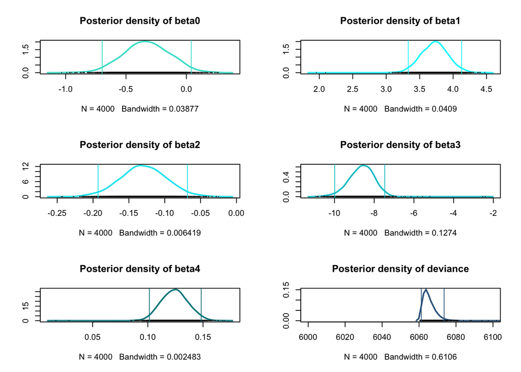

```r
par(mfrow = c(3, 2))
densplot(as.mcmc(logistic_jags4$BUGSoutput$sims.list$beta0), main = "Posterior density of beta0",
    col = "turquoise", lwd = 2)
abline(v = logistic_jags4$BUGSoutput$summary[1, 3], col = "turquoise")
abline(v = logistic_jags4$BUGSoutput$summary[1, 7], col = "turquoise")

densplot(as.mcmc(logistic_jags4$BUGSoutput$sims.list$beta1), main = "Posterior density of beta1",
    col = "turquoise1", lwd = 2)
abline(v = logistic_jags4$BUGSoutput$summary[2, 3], col = "turquoise1")
abline(v = logistic_jags4$BUGSoutput$summary[2, 7], col = "turquoise1")

densplot(as.mcmc(logistic_jags4$BUGSoutput$sims.list$beta2), main = "Posterior density of beta2",
    col = "turquoise2", lwd = 2)
abline(v = logistic_jags4$BUGSoutput$summary[3, 3], col = "turquoise2")
abline(v = logistic_jags4$BUGSoutput$summary[3, 7], col = "turquoise2")

densplot(as.mcmc(logistic_jags4$BUGSoutput$sims.list$beta3), main = "Posterior density of beta3",
    col = "turquoise3", lwd = 2)
abline(v = logistic_jags4$BUGSoutput$summary[4, 3], col = "turquoise3")
abline(v = logistic_jags4$BUGSoutput$summary[4, 7], col = "turquoise3")

densplot(as.mcmc(logistic_jags4$BUGSoutput$sims.list$beta4), main = "Posterior density of beta4",
    col = "turquoise4", lwd = 2)
abline(v = logistic_jags4$BUGSoutput$summary[5, 3], col = "turquoise4")
abline(v = logistic_jags4$BUGSoutput$summary[5, 7], col = "turquoise4")

densplot(as.mcmc(logistic_jags4$BUGSoutput$sims.list$deviance), main = "Posterior density of deviance",
    col = "steelblue4", lwd = 2, xlim = c(6000, 6100))
abline(v = logistic_jags4$BUGSoutput$summary[6, 3], col = "steelblue4")
abline(v = logistic_jags4$BUGSoutput$summary[6, 7], col = "steelblue4")
```

# Diagnostics

Autocorrelation indicates correlation between consecutive values on the chain. In order to avoid significant levels of autocorrelation, a thinning factor of 10 has been fixed.

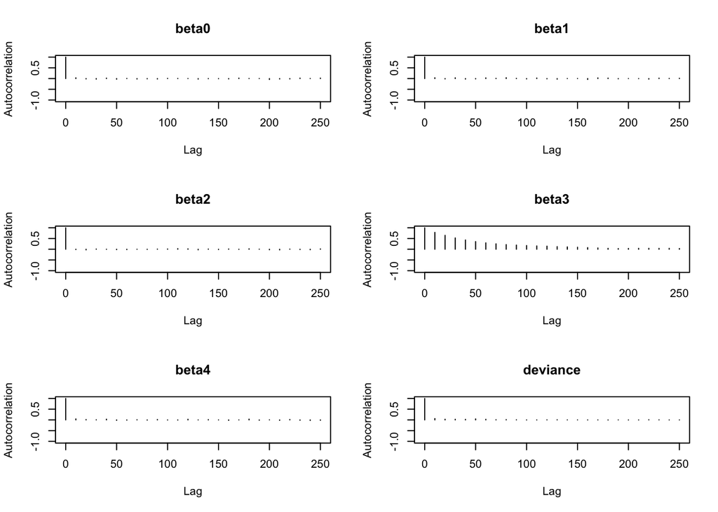

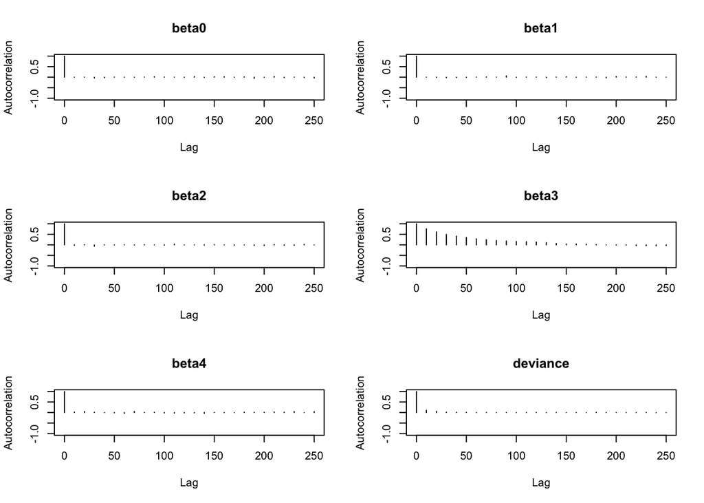

```r
library(coda)
autocorr.plot(as.mcmc(logistic_jags4))
```

In order to appraise convergence of the chains, we can take a look at the trace plots and the running means. These representations help us understand how quickly the chain reaches stationarity, namely how quickly it moves out of low probability regions and enters into high probability ones. The trace plot shows the sampled values for each iteration. Ideally a chain should oscillate quite often around the same region as this shows low levels of autocorrelation and the achievement of stationarity.

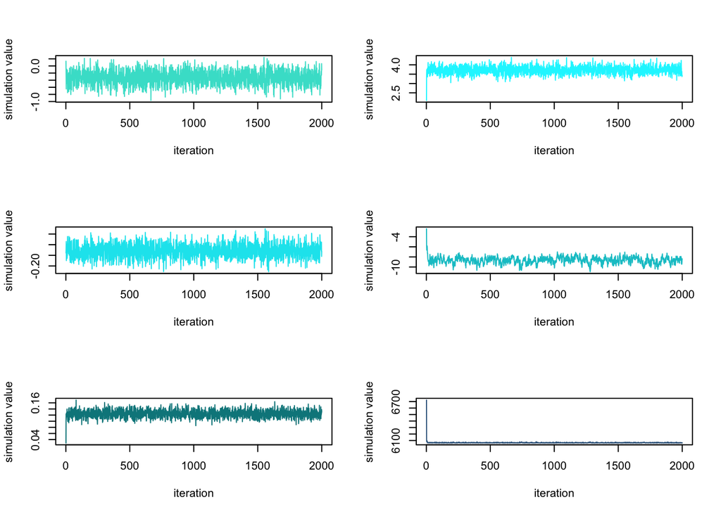

```r
par(mfrow = c(3, 2))

plot(logistic_jags4$BUGSoutput$sims.array[, 1, "beta0"], type = "l", col = "turquoise",
    ylab = "simulation value", xlab = "iteration")
plot(logistic_jags4$BUGSoutput$sims.array[, 1, "beta1"], type = "l", col = "turquoise1",
    ylab = "simulation value", xlab = "iteration")
plot(logistic_jags4$BUGSoutput$sims.array[, 1, "beta2"], type = "l", col = "turquoise2",
    ylab = "simulation value", xlab = "iteration")
plot(logistic_jags4$BUGSoutput$sims.array[, 1, "beta3"], type = "l", col = "turquoise3",
    ylab = "simulation value", xlab = "iteration")
plot(logistic_jags4$BUGSoutput$sims.array[, 1, "beta4"], type = "l", col = "turquoise4",
    ylab = "simulation value", xlab = "iteration")
plot(logistic_jags4$BUGSoutput$sims.array[, 1, "deviance"], type = "l", col = "steelblue4",
    ylab = "simulation value", xlab = "iteration")
```

The various states of sampled values are shown by the running means graph. At an early state, values present high variations, but subsequently more a stable behaviour appears. The sooner stationarity is reached by the chain, the better.

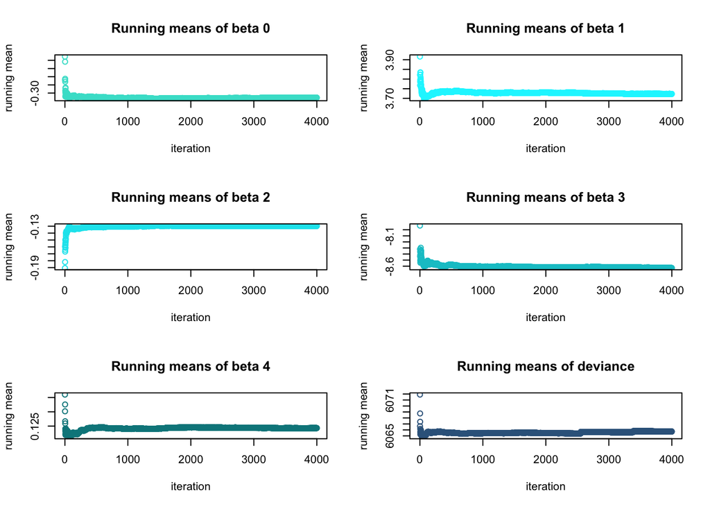

```r
val <- seq(1, 4000, by = 1)
par(mfrow = c(3, 2))

cs_beta0 <- cumsum(logistic_jags4$BUGSoutput$sims.list$beta0)
plot(val, cs_beta0/val, col = "turquoise", xlab = "iteration", ylab = "running mean",
    main = "Running means of beta 0")

cs_beta1 <- cumsum(logistic_jags4$BUGSoutput$sims.list$beta1)
plot(val, cs_beta1/val, col = "turquoise1", xlab = "iteration", ylab = "running mean",
    main = "Running means of beta 1")

cs_beta2 <- cumsum(logistic_jags4$BUGSoutput$sims.list$beta2)
plot(val, cs_beta2/val, col = "turquoise2", xlab = "iteration", ylab = "running mean",
    main = "Running means of beta 2")

cs_beta3 <- cumsum(logistic_jags4$BUGSoutput$sims.list$beta3)
plot(val, cs_beta3/val, col = "turquoise3", xlab = "iteration", ylab = "running mean",
    main = "Running means of beta 3")

cs_beta4 <- cumsum(logistic_jags4$BUGSoutput$sims.list$beta4)
plot(val, cs_beta4/val, col = "turquoise4", xlab = "iteration", ylab = "running mean",
    main = "Running means of beta 4")

cs_dev <- cumsum(logistic_jags4$BUGSoutput$sims.list$deviance)
plot(val, cs_dev/val, col = "steelblue4", xlab = "iteration", ylab = "running mean",
    main = "Running means of deviance")
```

```r
geweke.diag(logistic_jags4)
```

```
##
## Fraction in 1st window = 0.1
## Fraction in 2nd window = 0.5
##
##    beta0    beta1    beta2    beta3    beta4 deviance
##  -0.1787  -0.5545  -0.5631   0.7671  -1.8362   1.0477
```

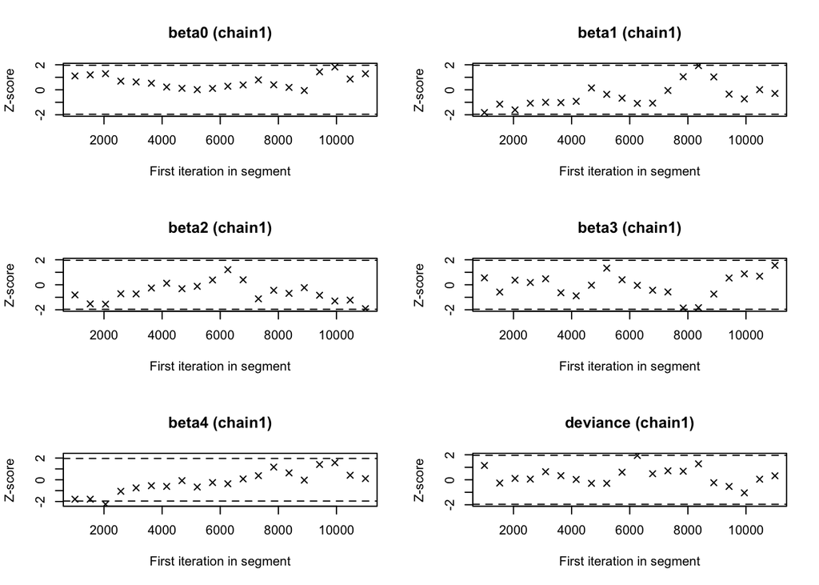

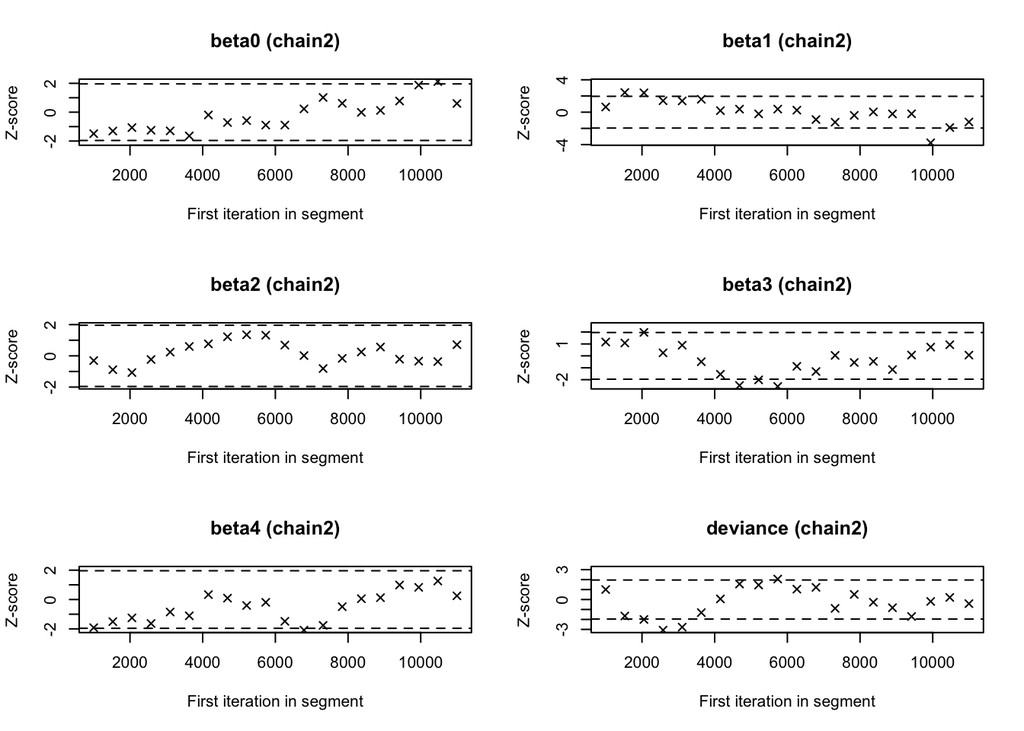

```r
geweke.plot(as.mcmc(logistic_jags4))
```

Gelman and Rubin's test performs a comparison of within-chain and between-chain variances. High values of the potential scale reduction factor (greater than 1.2) suggest us that we should run our chains out longer to improve convergence to the stationary distribution. The output of the Gelman and Rubin diagnostic gives us the median potential scale reduction factor and its 97.5% quantile.

```r
gelman.diag(as.mcmc(logistic_jags4))
```

```
## Potential scale reduction factors:
##
##          Point est. Upper C.I.
## beta0          1.00       1.00
## beta1          1.00       1.00
## beta2          1.00       1.00
## beta3          1.01       1.03
## beta4          1.00       1.00
## deviance       1.00       1.00
##
## Multivariate psrf
##
## 1.01
```

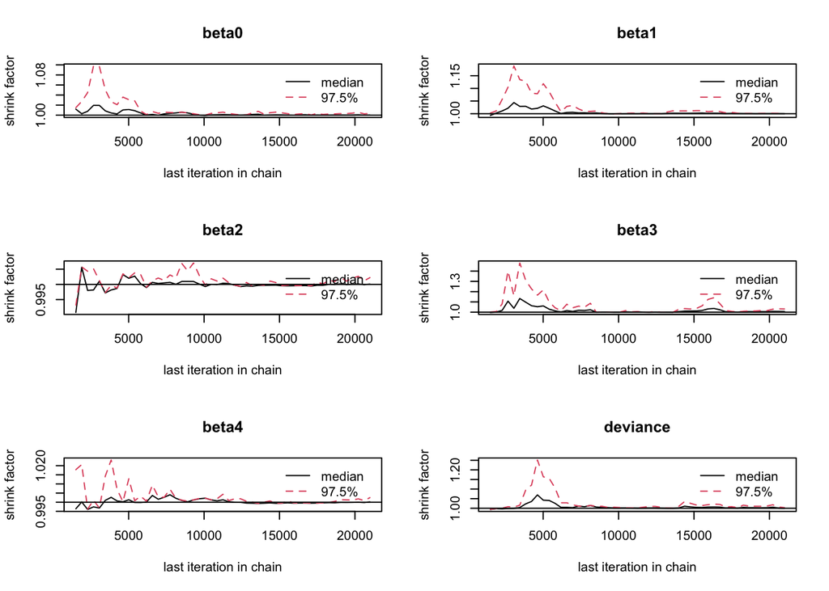

```r
gelman.plot(as.mcmc(logistic_jags4))
```

Effective Sample Size (ESS) and the Monte Carlo Standard Error(MCSE) are two other important quantities. The ESS due to autocorrelation is an estimate of the sample size necessary to obtain the same precision level had the sample been random, while MCSE is an estimate of the inaccuracy of Monte Carlo samples. For our data, the ESS is equal to 1864.068, and the MCSEs are very close to zero. These results prove once again that the hypothesis of convergence cannot be rejected.

```r
library("LaplacesDemon", lib.loc = "/Library/Frameworks/R.framework/Versions/4.0/Resources/library")

ESS(logistic_jags4$BUGSoutput$sims.array[, 1, "beta0"])
```

```
## [1] 1864.068
```

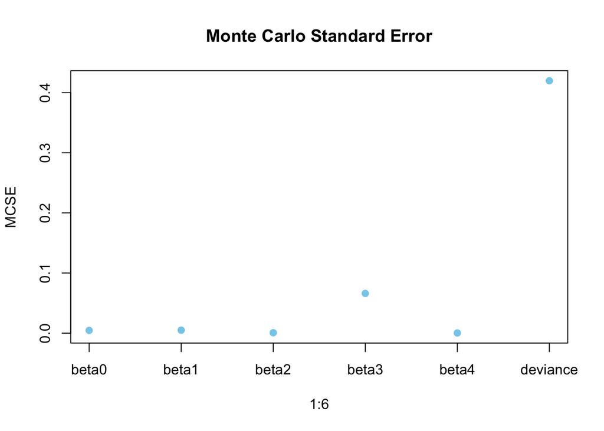

```r
SE_beta0 <- MCSE(logistic_jags4$BUGSoutput$sims.array[, 1, "beta0"])
SE_beta1 <- MCSE(logistic_jags4$BUGSoutput$sims.array[, 1, "beta1"])
SE_beta2 <- MCSE(logistic_jags4$BUGSoutput$sims.array[, 1, "beta2"])
SE_beta3 <- MCSE(logistic_jags4$BUGSoutput$sims.array[, 1, "beta3"])
SE_beta4 <- MCSE(logistic_jags4$BUGSoutput$sims.array[, 1, "beta4"])
SE_dev <- MCSE(logistic_jags4$BUGSoutput$sims.array[, 1, "deviance"])

SE <- c(SE_beta0, SE_beta1, SE_beta2, SE_beta3, SE_beta4, SE_dev)
par(mfrow = c(1, 1))
plot(1:6, SE, main = "Monte Carlo Standard Error", pch = 19, col = "skyblue", xaxt = "n",
    ylab = "MCSE")
axis(1, at = 1:6, labels = c("beta0", "beta1", "beta2", "beta3", "beta4", "deviance"))
```

# Prediction

Beyond using our Bayesian logistic regression model to better understand the relationship between predictors and the *target* variable, it could be interesting to predict whether a future observed song will be popular. Basically, we are enlarging our frame by including an additional observation $Y_{new}$. Suppose we want to find out if a new song with the following audio features will be popular or not:

- danceability: 0.7
- duration: 4
- instrumentalness: 0.1
- loudness: -8

By plugging in these values, we obtain the following specification:
$$\log(condexp) = \beta_0 + \beta_1*(danceability = 0.7) + \beta_2*(duration=4) + \beta_3 * (instrumentalness=0.1) + \beta_4*(loudness=-8)$$
$$Y_{new} \sim Bernoulli(condexp)$$
where *condexp* is the conditional expectation of $Y_{new}$, conditionally on the above specified values for the predictors. The conditional predictive distribution is estimated by JAGS.

```r
set.seed(1801282)
pred_parameters <- c("beta0", "beta1", "beta2", "beta3", "beta4", "ynew", "condexp")
logistic_prediction <- jags(data = D4, inits = inits, parameters.to.save = pred_parameters,
    model.file = "/Users/ccate/Desktop/OFFICIAL STATISTICS/BAYESIAN MODELLING/Progetti/logistic_model_prediction.txt",
    n.chains = 2, n.iter = 21000, n.thin = 10, n.burnin = 1000)
print(logistic_prediction)
```

```
## Inference for Bugs model at "/Users/ccate/Desktop/OFFICIAL STATISTICS/BAYESIAN MODELLING/Progetti/logistic_model_prediction.txt", fit using jags,
##  2 chains, each with 21000 iterations (first 1000 discarded), n.thin = 10
##  n.sims = 4000 iterations saved
##           mu.vect sd.vect     2.5%      25%      50%      75%    97.5%  Rhat
## beta0      -0.325   0.198   -0.700   -0.456   -0.325   -0.195    0.070 1.001
## beta1       3.723   0.207    3.321    3.584    3.722    3.862    4.115 1.001
## beta2      -0.131   0.033   -0.197   -0.152   -0.131   -0.108   -0.068 1.001
## beta3      -8.583   0.618   -9.785   -8.999   -8.568   -8.175   -7.463 1.005
## beta4       0.124   0.012    0.102    0.116    0.124    0.132    0.148 1.001
## condexp     0.477   0.017    0.444    0.465    0.477    0.488    0.509 1.002
## ynew        0.467   0.499    0.000    0.000    0.000    1.000    1.000 1.001
## deviance 6065.606  14.508 6061.175 6063.004 6064.598 6066.801 6073.188 1.003
##          n.eff
## beta0     4000
## beta1     2300
## beta2     4000
## beta3      330
## beta4     4000
## condexp   1700
## ynew      4000
## deviance  4000
##
## For each parameter, n.eff is a crude measure of effective sample size,
## and Rhat is the potential scale reduction factor (at convergence, Rhat=1).
##
## DIC info (using the rule, pD = var(deviance)/2)
## pD = 105.3 and DIC = 6170.9
## DIC is an estimate of expected predictive error (lower deviance is better).
```

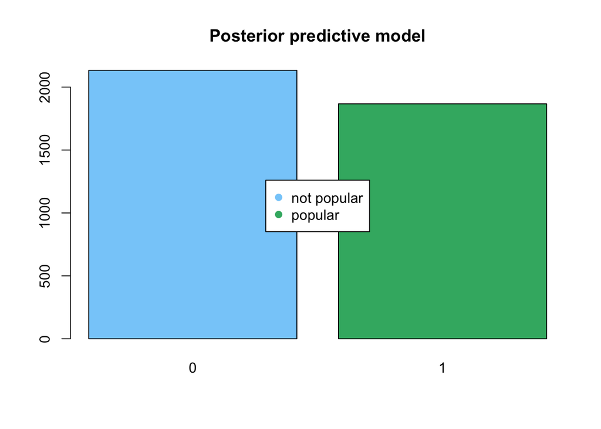

```r
par(mfrow = c(1, 1))
barplot(table(logistic_prediction$BUGSoutput$sims.matrix[, "ynew"]), main = "Posterior predictive model",
    col = c("lightskyblue", "mediumseagreen"))
legend("center", legend = c("not popular", "popular"), col = c("lightskyblue", "mediumseagreen"),
    pch = 19)
```

```r
table(logistic_prediction$BUGSoutput$sims.matrix[, "ynew"])
```

```
##
##    0    1
## 2133 1867
```

The estimated value of $Y_{new}$ is 0.47 and it is quite close to the estimation of the conditional expectation (0.48). Here, our Bayesian logistic regression model suggests that the event $target_{y_{new}} = 0$ is slightly more likely than $target_{y_{new}} = 1$.

# Model comparison

In the past paragraphs we implemented a MCMC estimation for the regression cofficients $\beta_k$ for $k=1,2,3,4$ associated to the respective predictors: $X_1$ = danceability, $X_2$ = duration, $X_3$ = instrumentalness and $X_4$ = loudness. Now we offer an alternative model that does not include $X_2$:
$$\log(\frac{\theta_i}{ 1-\theta_i}) = \beta_0 + \beta_1*danceability_i + \beta_3 * instrumentalness_i + \beta_4*loudness_i$$

```r
set.seed(1801282)
D3 <- list(popularity = reduced_dataset$target, danceability = reduced_dataset$danceability,
    instrumentalness = reduced_dataset$instrumentalness, loudness = reduced_dataset$loudness,
    N = nrow(reduced_dataset))
str(D3)
```

```
## List of 5
##  $ popularity      : num [1:6398] 1 0 1 0 1 1 0 1 0 1 ...
##  $ danceability    : num [1:6398] 0.741 0.447 0.55 0.502 0.807 0.482 0.533 0.736 0.166 0.387 ...
##  $ instrumentalness: num [1:6398] 0 0.814 0 0 0 0 0 0 0.0142 0 ...
##  $ loudness        : num [1:6398] -4.83 -14.66 -6.56 -5.7 -3.89 ...
##  $ N               : int 6398
```

```r
parameters <- c("beta0", "beta1", "beta3", "beta4")
init_1 <- list(beta0 = 1, beta1 = 0, beta3 = 0, beta4 = 0)
init_2 <- list(beta0 = 0, beta1 = 0, beta3 = 0, beta4 = 0)
inits <- list(init_1, init_2)
logistic_jags3 <- jags(data = D3, inits = inits, parameters.to.save = parameters,
    n.chains = 2, n.iter = 21000, n.thin = 10, n.burnin = 1000, model.file = "/Users/ccate/Desktop/OFFICIAL STATISTICS/BAYESIAN MODELLING/Progetti/logistic_model3.txt")
print(logistic_jags3)
```

```
## Inference for Bugs model at "/Users/ccate/Desktop/OFFICIAL STATISTICS/BAYESIAN MODELLING/Progetti/logistic_model3.txt", fit using jags,
##  2 chains, each with 21000 iterations (first 1000 discarded), n.thin = 10
##  n.sims = 4000 iterations saved
##           mu.vect sd.vect     2.5%      25%      50%      75%    97.5%  Rhat
## beta0      -0.898   0.135   -1.160   -0.994   -0.896   -0.807   -0.639 1.001
## beta1       3.892   0.199    3.502    3.762    3.893    4.025    4.281 1.001
## beta3      -8.775   0.630  -10.020   -9.172   -8.766   -8.361   -7.634 1.003
## beta4       0.127   0.012    0.104    0.120    0.127    0.136    0.151 1.001
## deviance 6081.429  14.236 6077.630 6079.035 6080.434 6082.462 6088.026 1.001
##          n.eff
## beta0     4000
## beta1     4000
## beta3      970
## beta4     4000
## deviance  4000
##
## For each parameter, n.eff is a crude measure of effective sample size,
## and Rhat is the potential scale reduction factor (at convergence, Rhat=1).
##
## DIC info (using the rule, pD = var(deviance)/2)
## pD = 101.4 and DIC = 6182.8
## DIC is an estimate of expected predictive error (lower deviance is better).
```

Now, the interpretation of the intercept is more clear, as it is easier to picture a song with scores of *danceability*, *instrumentalness* and *loudness* equal to zero. Being $\hat\beta_0 = -0.898$, the corresponding odds ratio is equal to 0.41, suggesting that the event of "non-popularity" is more likely:
$$\theta_i = \frac{exp(-0.898)}{1+exp(-0.898)} = 0.29$$
As for the remaining coefficients, they do not encounter major modifications with respect to the previous, more complex model. In order to properly compare the two models, we use the Deviance Information Criteria (DIC). It consists in a generalization of the Akaike Information Criterion (AIC) and it measures the trade-off between the deviance and the number of parameters selected. The smaller the deviance, the better the fit of the model, but we also have to avoid to select a too large number of parameters due to the fact that the deviance decreases gradually as the number of predictors grows. The DIC is therefore defined as the sum between two components, one representing the goodness of fit and the other one indicating the model complexity (namely, effective number of parameters):
$$DIC = D_{\hat\theta}(y) + 2p_D$$
As lower values of DIC are to be preferred, we may notice that the JAGS outputs for the two models are in favour of the first, more detailed model.

```r
logistic_jags3$BUGSoutput$DIC
```

```
## [1] 6182.78
```

```r
logistic_jags4$BUGSoutput$DIC
```

```
## [1] 6171.546
```

# Comparison between Bayesian and frequentist analysis

In this section, we will carry out a simple frequentist analysis on the same dataset we have been studying via Bayesian approach. From now on, unknown parameters will be considered as fixed, so they are no longer modeled as random variables. Therefore, our simple logistic regression will still have the *target* variable as dependent variable and *danceability*, *duration*, *instrumentalness*, *loudness* as predictors:
$$\log(\frac{\theta_i}{ 1-\theta_i}) = \beta_0 + \beta_1*danceability_i + \beta_2*duration_i + \beta_3 * instrumentalness_i + \beta_4*loudness_i$$

```r
simple_logistic_reg <- glm(target ~ danceability + duration + instrumentalness +
    loudness, data = reduced_dataset, family = binomial(link = "logit"))
summary(simple_logistic_reg)
```

```
##
## Call:
## glm(formula = target ~ danceability + duration + instrumentalness +
##     loudness, family = binomial(link = "logit"), data = reduced_dataset)
##
## Deviance Residuals:
##     Min       1Q   Median       3Q      Max
## -2.2544  -0.8340   0.2071   0.8340   4.2354
##
## Coefficients:
##                  Estimate Std. Error z value Pr(>|z|)
## (Intercept)      -0.32513    0.19499  -1.667   0.0954 .
## danceability      3.71467    0.20263  18.332  < 2e-16 ***
## duration         -0.12962    0.03232  -4.011 6.05e-05 ***
## instrumentalness -8.54859    0.59893 -14.273  < 2e-16 ***
## loudness          0.12401    0.01200  10.330  < 2e-16 ***
## ---
## Signif. codes:  0 '***' 0.001 '**' 0.01 '*' 0.05 '.' 0.1 ' ' 1
##
## (Dispersion parameter for binomial family taken to be 1)
##
##     Null deviance: 8869.5  on 6397  degrees of freedom
## Residual deviance: 6060.3  on 6393  degrees of freedom
## AIC: 6070.3
##
## Number of Fisher Scoring iterations: 8
```

As expected, the coefficients are very close to those ones estimated earlier by JAGS, probably because we assumed a very low informative prior distribution.

### JAGS model specificatons

```
### Logistic regression with 4 predictors
model {
        for (i in 1:N) {
            popularity[i] ~ dbern(p[i])

            logit(p[i]) <- beta0 + beta1*danceability[i] + beta2*duration[i] + beta3*instrumentalness[i] + beta4*loudness[i]

        }

        # setting up priors
        beta0 ~ dnorm(0, 0.0001)
        beta1 ~ dnorm(0, 0.0001)
        beta2 ~ dnorm(0, 0.0001)
        beta3 ~ dnorm(0, 0.0001)
        beta4 ~ dnorm(0, 0.0001)

}
```

```
### Prediction model
model {
        for (i in 1:N) {
            popularity[i] ~ dbern(p[i])

            logit(p[i]) <- beta0 + beta1*danceability[i] + beta2*duration[i] + beta3*instrumentalness[i] + beta4*loudness[i]

        }
        # prediction
        ynew ~ dbern(condexp)
        logit(condexp) <- beta0 + beta1*0.7 + beta2*4 + beta3*0.1 + beta4*-8)
        # setting up priors
        beta0 ~ dnorm(0, 0.0001)
        beta1 ~ dnorm(0, 0.0001)
        beta2 ~ dnorm(0, 0.0001)
        beta3 ~ dnorm(0, 0.0001)
        beta4 ~ dnorm(0, 0.0001)

}
```

```
### Logistic regression with 3 predictors
model {
        for (i in 1:N) {
            popularity[i] ~ dbern(p[i])

            logit(p[i]) <- beta0 + beta1*danceability[i] + beta3*instrumentalness[i] + beta4*loudness[i]

        }

        # setting up priors
        beta0 ~ dnorm(0, 0.0001)
        beta1 ~ dnorm(0, 0.0001)
        beta3 ~ dnorm(0, 0.0001)
        beta4 ~ dnorm(0, 0.0001)

}
```